# Interpolación Piura

## Interpolación de la precipitación de la región Piura

La interpolación es un proceso matemático que se utiliza para estimar valores desconocidos o faltantes en un conjunto de datos conocidos. En el contexto de la precipitación, la interpolación se utiliza para estimar los valores de precipitación en ubicaciones específicas dentro de un área geográfica basándose en datos disponibles en estaciones meteorológicas u otros puntos de muestreo. Se utilizan diferentes métodos matemáticos, como la interpolación espacial o temporal, para generar mapas y representaciones que muestran la distribución detallada de la precipitación. Esto es importante para comprender y analizar los patrones de precipitación, así como para tomar decisiones informadas en áreas como la gestión del agua, la planificación urbana y la adaptación al cambio climático. Los métodos de interpolación, como el de vecinos más cercanos o el kriging, son utilizados para estimar los valores desconocidos de manera precisa y coherente.

La interpolación de la precipitación es crucial por varias razones:  
1. Rellena los datos faltantes  
2. Permite el análisis espacial  
3. Mejora la modelización hidrológica  
4. Contribuye a los estudios climáticos y el cambio climático  
5. Ayuda en la planificación y gestión de riesgos.

### Paquetes

```r
library(pacman)
p_load(raster,sf,sp,spdep,gstat,rgdal,reshape2,ggplot2,RColorBrewer,readxl)
```

### Lectura de datos

```r
region <- read.csv("Piura.csv") #Carga de los datos donde se encuentran las coordenas y la precipitación
coordinates(region)<- ~longitud + latitud #coordinates brinda las coordenadas
head(region)
```

```
##   orden       localidad altitud precipitacion
## 1     1         Ayabaca    2648      50366.33
## 2     2          bernal      11       2612.62
## 3     3      Chulucanas      89      13288.02
## 4     4          Chusis       8       2505.13
## 5     5 Hacienda Bigote     198      19465.81
## 6     6 Hacienda Sumaya    1975      37003.72
```

**Un archivo Shapefile contiene al menos**  
.shp - un archivo tipo shape, es la geometría misma.  
.shx - un archivo tipo index, tiene las posiciones indexadas del archivo .shp.  
.dbf - un archivo tipo attribute, tiene los atributos de cada forma en una columna, es de tipo dBase IV.

### Lectura shapefile de la región Piura

```r
#DEPARTAMENTOS.shp contiene las siluetas de cada departamento del Perú
peru <- st_read("DEPARTAMENTOS.shp")[0] #st_read permite la lectura de archivos en formato shapefile (shp)
```

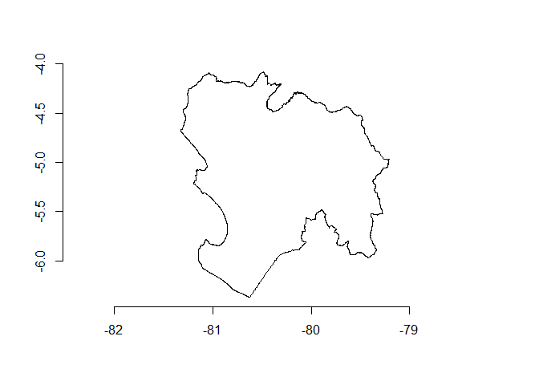

```r
piura<-peru[20,1] #Silueta de Piura
plot(piura) #Grafica de la silueta de piura
axis(1) #Eje x
axis(2) #Eje y
```

Una vez obtenida la silueta de la región Piura vamos a utilizarlo como molde para poder realizar la interpolación dentro de ella.

### Interpolación

*Área del rectangulo**  
Creación de una malla rectangular lleno de puntos en función al tamaño de la silueta de piura.

```r
e<-extent(piura) #extent toma los valores minimo y maximo de las coordenadas
grd<-expand.grid(x=seq(from=e[1],to=e[2],by=0.01), y=seq(from=e[3],to=e[4],by=0.01)) #expand.grid crea un dataframe de puntos (malla rectangular), se ingresa como parametros los valores extremos ya calculados con un intervalo entre punto y punto de 0.01
coordinates(grd)<- ~x + y #Formato de coordenadas
gridded(grd)<- TRUE # Explica que los datos espaciales estan cuadriculados
crs(grd)<-crs(shapefile)
```

**Generar los nuevos valores para los puntos creados**

```r
nuevo<-idw(precipitacion/39 ~ 1, region,grd) #idw genera los valores en funcion de la precipitación para cada punto creado
```

```
## [inverse distance weighted interpolation]
```

```r
nuevo<-raster(nuevo) #raster crea objetos de tipo raster que representan información geoespacial en forma de una cuadrícula regular.
```

**Solo region Piura**

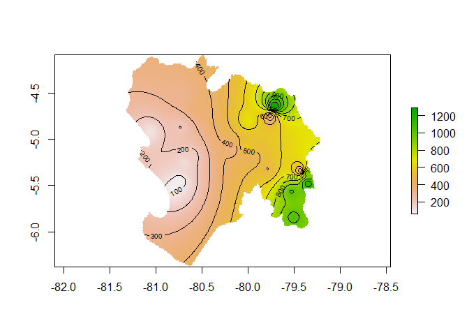

```r
nuevo1<-raster::mask(nuevo,piura) #mask crea una mascara en función a las coordenadas de la malla nueva y la silueta
plot(nuevo1)
contour(nuevo1,add=TRUE,axes=FALSE) #Grafico de interpolación de precipitación de la región Piura
```

```r
#contour dibuja el contorno según la precipitación
```

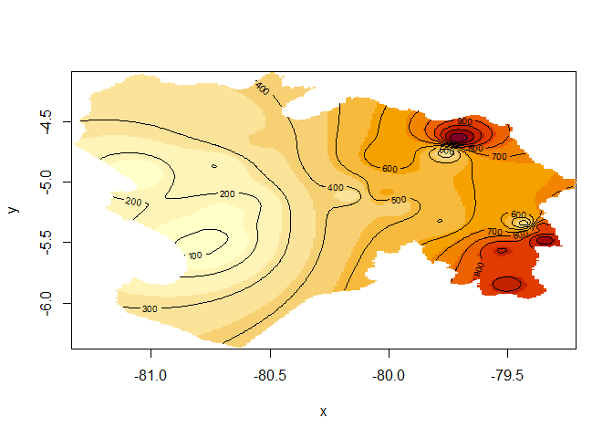

```r
image(nuevo1)
contour(nuevo1,add=TRUE,axes=FALSE) #Grafico de interpolación de precipitación de la región Piura usando image
```

**Imagen generada con ggplot**

```r
ppt.df<-as.data.frame(nuevo1,xy=TRUE) %>%
  melt(id.vars=c("x","y"))
```

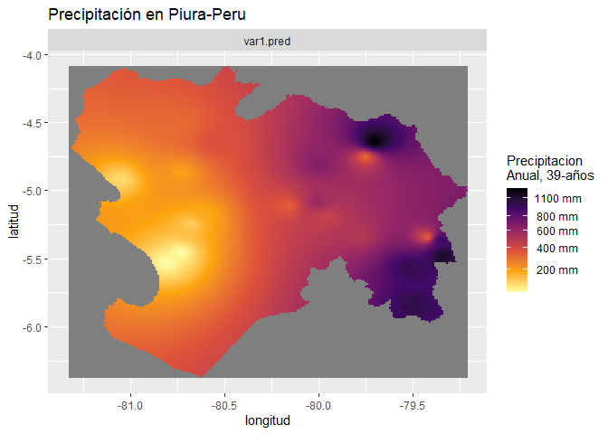

```r
ggplot()+
  geom_raster(data=ppt.df, aes(x=x,y=y, fill=value))+
  facet_wrap(~variable)+
  labs(x="longitud",y="latitud")+
  scale_fill_viridis_c(option = "B",   direction = -1,
  trans = "sqrt",
  breaks = c(200,  400,  600,  800, 1100, 1400),
  labels = c(" 200 mm", " 400 mm", " 600 mm", " 800 mm", "1100 mm", "1400 mm"),
  name = "Precipitacion\nAnual, 39-años")+
  ggtitle("Precipitación en Piura-Peru")
```

Como conclusión podemos observar en la grafica que existen zonas de la región con alta precipitación, mientras más intenso sea el color mayor sera la precipitación, este es el caso de las zonas que estan de un color más oscuro (morado oscuro), estas zonas presentan una precipitación entre 800 a 1100 mm en promedio por año aproximadamente. Mientras que las zonas con baja precipitación se encuentran de un color más claro (amarillo-naranja), el nivel de pricipitación en toda esta zona varia entre 0 a 400 mm en promedio por año aproximadamente, siendo esto la que cubre la mayor parte de la región Piura.

Gracias al presente estudio es posible identificar patrones espaciales y tendencias en la distribución de la precipitación. Se pueden observar áreas con altos valores de precipitación, indicando regiones propensas a lluvias intensas o eventos climáticos extremos. También se pueden identificar áreas con bajos valores de precipitación, que pueden indicar regiones con condiciones de sequía o escasez de lluvias.